# Your Digest for Friday, Sep 01, 2023 11:59 PM

[[2021-Basic Sciences#Glucose regulating hormones|IGF]] <<- **Action of IGF**

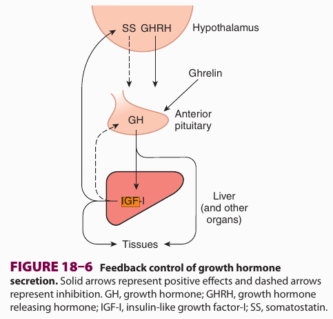

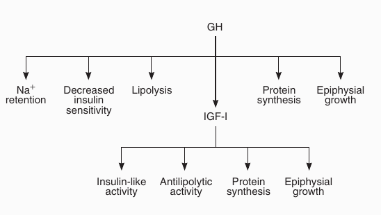

> [!TIP] IGF Vs. GH Vs. Insulin  
> Despite GH having anti-insulin effects, IGF-1 has insulin like activity

Parathyroid hormone secretion is directly inhibited by high calcium levels.  
This happens through **binding of calcium to a GPCR** on the parathyroid cells called **CaR**.

**Magnesium** is needed for the action of PTH. Hypomagnesaemia impairs PTH release and impairs peripheral organ sensitivity to PTH.

# Frank-Starling curves

**Mechanism of the Frank starling effect**:  
It is not simply due to increased overlap of the actin and myosin filaments with increased myocardial stretching.  
It has been shows that increased myocardial stretching leads to

1. increased affinity of troponin for calcium
2. myocardial calcium handling.

In addition to increased overlap, these effects increase contractile force. [Source](https://cvphysiology.com/cardiac-function/cf003)

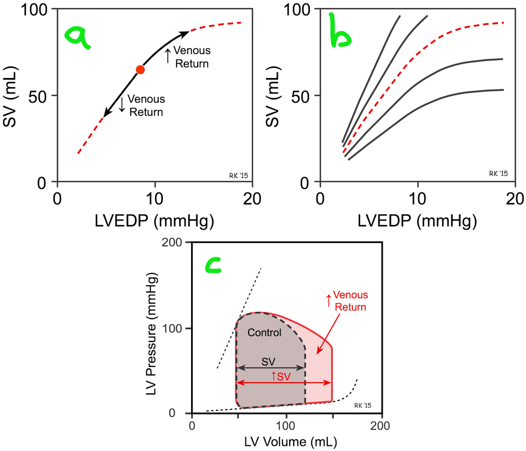

Note the axes in these graphs:  
a - shows the effects of changing preload on the stroke volume.  
b - shows the a family of Frank-starling curves for different inotropic statuses of the heart.  
c - the *pressure - volume* diagram of the heart.

## Pressure volume diagrams

### End systolic pressure volume relationship and End diastolic PVR

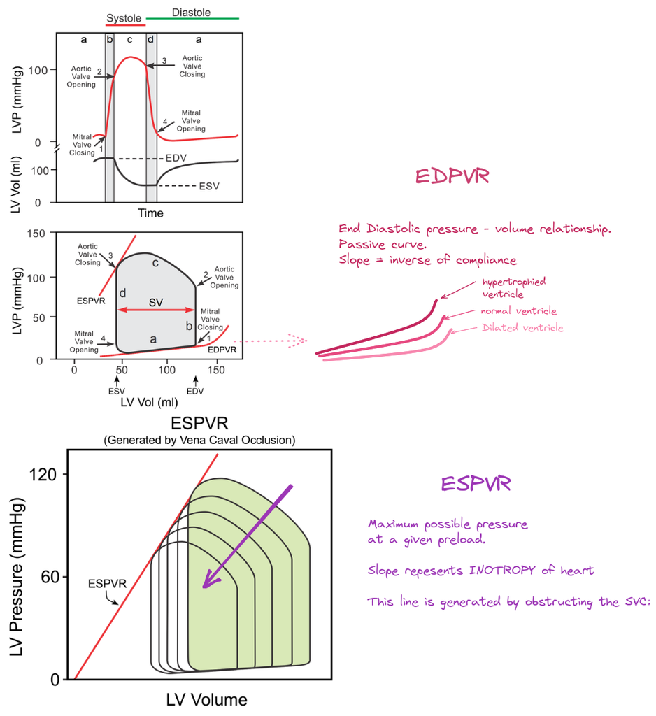

## Effects of preload, afterload and inotropy on stroke volume

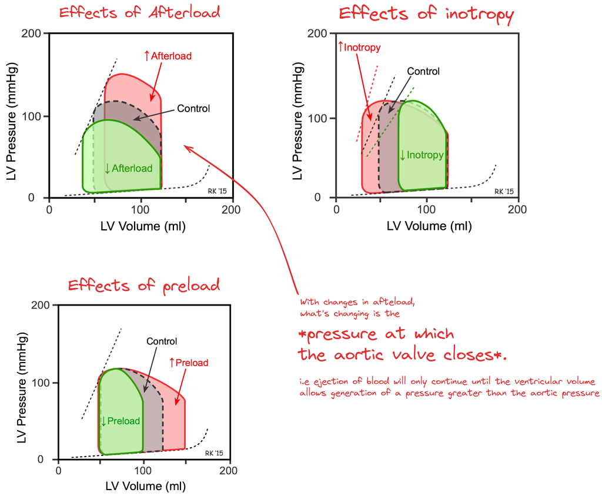

# Arteriovenous malformation

#2021BSQ-NOV Q05

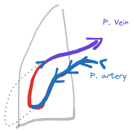

- Pulmonary arteriovenous malformation (PAVM)
- Most commonly associated with **Hereditary haemorrhagic telangiectasia**.
- Acquired causes of PAVM are hepatopumonary syndrome, fanconi syndrome, actinomycosis, surgery, trauma etc.
- Connection between the *pulmonary artery and pulmonary vein* -> Pathologic **right to left shunt*.
- Consider in a patient have epistaxis, hypoxemia and exertional dysponoea.
- Anatomy:
  - They aren't 'proper' blood vessels : PAVM consists of thin-walled vascular channels that are built by elastic fibers and remnants of smooth muscle cells.
  - Usually unilateral
  - Found in the lower pleura of the lower lobes

# Interstitial lung diseases

[Source](https://pathologia.ed.ac.uk/topic/interstitial-lung-disease/)  
[Source](https://jcp.bmj.com/content/62/5/387)  
[Source](https://sci-hub.se/https://doi.org/10.1038/nrrheum.2014.149)

A diverse set of conditions which cause fibrosis of the 'interstitial tissues' of the lungs.  
Interstitium = basement membranes of the avleorlar cells and capillary endothelium + fibroblasts and phagocytic cells present.

Pathogenesis involves repeated cell injury and TGF-beta 1 mediated fibrogenesis.

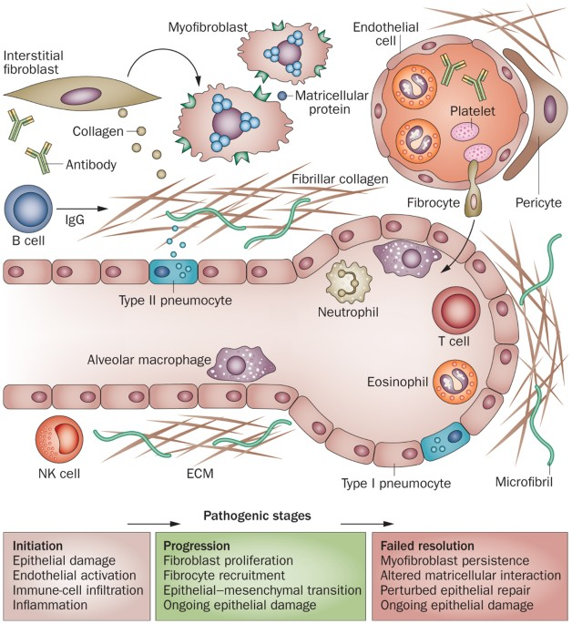

Fibrogenesis = reduced compliance = **restrictive** pattern. This is a hallmark of the interstitial lung diseases.

## Effect on respiratory physiology

> In concert with alterations of the alveolar–capillary membrane, these lesions impair  
> both **gas diffusion** and **ventilation/perfusion (*V*′/*Q*′) relationships** in the lung  
> [Source](https://err.ersjournals.com/content/27/147/170062)

> [!TIP] The two components of lung function
> - Unimpaired Gas diffusion
> - Matched Ventilation / perfusion

Features of interstitial fibrosis:

- reduced diffusing capacity of the lung,
- increased dead space ventilation,
- and increases in the alveolar–arterial oxygen tension difference
- and chronic arterial hypoxaemia
- *DLCO is definitely reduced.* [Source](https://err.ersjournals.com/content/27/147/170062)
- They have increased V/Q ratio (i.e more dead space due to increase in non-gas exchanging areas)

## Flow - volume loops

[Source](https://www.msdmanuals.com/professional/pulmonary-disorders/tests-of-pulmonary-function-pft/airflow,-lung-volumes,-and-flow-volume-loop)

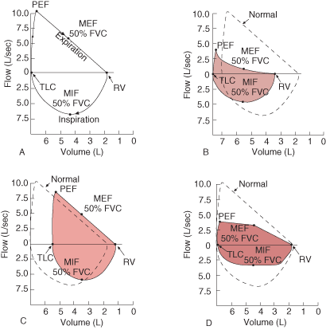

> The principal advantage of the flow-volume loop is that it can show whether airflow is appropriate for a particular lung volume. For example, airflow is normally slower at low lung volumes because **elastic recoil is lower at lower lung volumes.**

# Glucose regulating hormones

- Adiponectin
  - Mnemonic: Effects of adiponectin tend to reduce blood glucose levels.
  - Is an "Adipokine" and is produced by adipocytes.
  - Increased adiponectin levels are associated with increased insulin sensitivity.
  - Studies have show that high adiponecting increases insulin sensitivity and vice versa.
  - Calory restriction and weight loss increase the levels of adiponectin.
  - Levels are decreased in states of insulin resistance.
  - Adiponectin may have protective action against cancers, atherogenesis and obesity associated diseases.
  - Summary of actions of adiponecing: [Source](https://www.ncbi.nlm.nih.gov/pmc/articles/PMC7554603/)

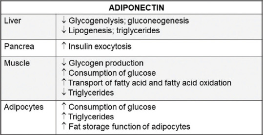

- **IGF**
  - IGF-I and IGF-II are **somatomedins**. They are required for the action of growth hormone.
  - They are peptides similar in structure to insulin and are produced in the liver.
  - [[Hormone Physiology#Growth hormone]]

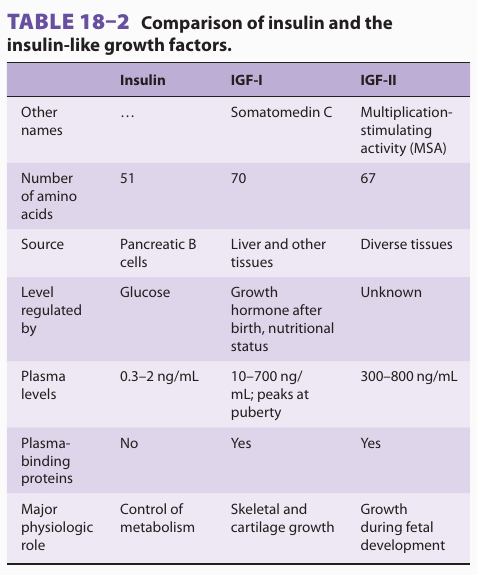

  - [[IGFInsulinLikeGrowthFactorActions.png]]
  - IGF-I peaks in puberty and it's main role is skeletal and cartilage growth. It is stimulated by GH.
  - IGF-II is only important in foetal development (and it not sensitive to GH regulation)
- **Leptin** -
  - The discovery of leptin led to the view of adipose tissue as an endocrine organ and not merely as a passive energy storage organ.
  - Leptin is a peptide hormone synthesized by adipose tissue. Overall, it regulates the balance between food intake and energy expenditure. Leptin produced by adipose tissue acts as a signal for the CNS (main site of action is brain stem and hypothalamus) to detect adequate energy reserves.
  - Low leptin -> means low energy reserves -> CNS triggers energy saving measures (decreased metabolisme etc) and increased apetite.
  - High leptin -> means increased adipose tissue -> means good energy reserves -> energy expenditure promoted along with decreased apetite.
  - Leptin deficiency
    - Complete leptin deficiency results in the clinical phenotypes of severe obesity, impaired satiety (and food seeking behaviour), intensive hyperphagia, constant food-seeking behavior, recurrent bacterial infections, hyperinsulinemia, liver steatosis, dyslipidemia, and hypogonadotropic hypogonadism.
  - Converserly, hyperleptinaemia means leptin resistance; these people also have obesity.
  - Humans with congenital leptin deficiency have insulin resistance and other features of the metabolic syndrome. In the *ob/ob* mouse strain, leptin treatment improves hyperglycemia and hyperinsulinemia before weight loss is achieved
  - Leptin tends to reduce blood glucose (at least in mice)
  - [Source](https://www.ncbi.nlm.nih.gov/pmc/articles/PMC2829242/)
  - [Source](https://www.ncbi.nlm.nih.gov/pmc/articles/PMC4020728/)
  - [Source](https://www.ncbi.nlm.nih.gov/books/NBK537038/)

> The increase in the alveolar to arterial oxygen gradient with rising concentrations of carboxyhemoglobin results from changes induced by carbon monoxide **in the shape of the oxyhemoglobin dissociation curve.** - [Source](https://pubmed.ncbi.nlm.nih.gov/5770624/)

#2021BSQ-NOV Q05  
**Increased** in defects of alveolar / capillary unit.  
**Normal** in defects of oxygen delivery. (because PAO2 and PaO2 are both reduced)